# COVID deaths per population

This lesson uses COVID case data from the New York Times and Kyle Walker’s [tidycensus](https://walker-data.com/tidycensus/index.html) package to make a map of COVID deaths per popluation for Texas counties. See [Reporting with Data in R] for more information.

As of this writing, the [RWDIR chapter for this is here](https://utdata.github.io/rwdir/census-more.html).

## Setup

```r
library(tidyverse)
library(janitor)
library(tidycensus)
```

## Import covid data

The data is found [here](https://github.com/nytimes/covid-19-data).

```r
covid <- read_csv("https://raw.githubusercontent.com/nytimes/covid-19-data/master/us-counties.csv") %>%
  clean_names()
covid %>% head(10)
```

| date | county | state | fips | cases | deaths |
| --- | --- | --- | --- | --- | --- |
| 2020-01-21 | Snohomish | Washington | 53061 | 1 | 0 |
| 2020-01-22 | Snohomish | Washington | 53061 | 1 | 0 |
| 2020-01-23 | Snohomish | Washington | 53061 | 1 | 0 |
| 2020-01-24 | Cook | Illinois | 17031 | 1 | 0 |
| 2020-01-24 | Snohomish | Washington | 53061 | 1 | 0 |
| 2020-01-25 | Orange | California | 06059 | 1 | 0 |
| 2020-01-25 | Cook | Illinois | 17031 | 1 | 0 |
| 2020-01-25 | Snohomish | Washington | 53061 | 1 | 0 |
| 2020-01-26 | Maricopa | Arizona | 04013 | 1 | 0 |
| 2020-01-26 | Los Angeles | California | 06037 | 1 | 0 |

Get most recent Texas numbers.

There is an “Unknown” county, which we remove.

```r
tx_covid <- covid %>%
  filter(state == "Texas") %>%
  group_by(county) %>%
  slice_max(date) %>%
  select(-state) %>%
  filter(county != "Unknown")

tx_covid
```

| date | county | fips | cases | deaths |
| --- | --- | --- | --- | --- |
| 2021-10-24 | Anderson | 48001 | 8001 | 199 |
| 2021-10-24 | Andrews | 48003 | 2795 | 53 |
| 2021-10-24 | Angelina | 48005 | 13665 | 397 |
| 2021-10-24 | Aransas | 48007 | 2590 | 66 |
| 2021-10-24 | Archer | 48009 | 1237 | 19 |
| 2021-10-24 | Armstrong | 48011 | 285 | 7 |
| 2021-10-24 | Atascosa | 48013 | 8521 | 202 |
| 2021-10-24 | Austin | 48015 | 3484 | 51 |
| 2021-10-24 | Bailey | 48017 | 1004 | 23 |
| 2021-10-24 | Bandera | 48019 | 2309 | 51 |

[output cut: 244 more lines]

## Get population data

First we have to figure out the variable we want. We are using 2020 Decennial data from the redistricting file. This is [the table](https://data.census.gov/cedsci/table?q=P1&tid=DECENNIALPL2020.P1) from data.census.gov that has the population info.

Download the variables from the “pl” table:

```r
vpl <- load_variables(2020, "pl", cache = T)
# view is commented out
# View(vpl)
```

The total population variable is: P1_001N

Test the variable against the portal:

```r
get_decennial(
  year = 2020,
  variables = c(total_pop = "P1_001N"),
  geography = "state",
  state = "AL"
)
```

```
## Using the PL 94-171 Redistricting Data summary file
```

```
## Note: 2020 decennial Census data use differential privacy, a technique that
## introduces errors into data to preserve respondent confidentiality.
## ℹ Small counts should be interpreted with caution.
## ℹ See https://www.census.gov/library/fact-sheets/2021/protecting-the-confidentiality-of-the-2020-census-redistricting-data.html for additional guidance.
```

| GEOID | NAME | variable | value |
| --- | --- | --- | --- |
| 01 | Alabama | total_pop | 5024279 |

Now let’s get Texas by county. The output is suppressed.

```r
tx_pop <- get_decennial(
  year = 2020,
  variables = c(total_pop = "P1_001N"),
  geography = "county",
  state = "TX",
  geometry = TRUE # adds shapes
) %>% clean_names()
```

## Join the data

We use an inner join to bring the covid data into the population data.

> You have to start with the population data for the geometry to work.

```r
tx_joined <- tx_pop %>%
  # this is the join line
  inner_join(tx_covid, by = c("geoid" = "fips"))

tx_joined %>% glimpse()
```

```
## Rows: 254
## Columns: 9
## $ geoid    <chr> "48005", "48225", "48373", "48473", "48441", "48055", "48355"…
## $ name     <chr> "Angelina County, Texas", "Houston County, Texas", "Polk Coun…
## $ variable <chr> "total_pop", "total_pop", "total_pop", "total_pop", "total_po…
## $ value    <dbl> 86395, 22066, 50123, 56794, 143208, 45883, 353178, 31040, 201…
## $ geometry <MULTIPOLYGON [°]> MULTIPOLYGON (((-95.00488 3..., MULTIPOLYGON (((…
## $ date     <date> 2021-10-24, 2021-10-24, 2021-10-24, 2021-10-24, 2021-10-24, …
## $ county   <chr> "Angelina", "Houston", "Polk", "Waller", "Taylor", "Caldwell"…
## $ cases    <dbl> 13665, 2847, 5900, 6461, 22777, 8376, 61305, 4308, 4736, 898,…
## $ deaths   <dbl> 397, 80, 198, 79, 542, 150, 1245, 126, 110, 28, 250, 156, 318…
```

### Clean up the columns

Removing columns and renaming value.

```r
tx_selected <- tx_joined %>%
  select(-c(date, name, variable)) %>%
  rename(
    total_pop = value
  )

tx_selected %>% glimpse()
```

```
## Rows: 254
## Columns: 6
## $ geoid     <chr> "48005", "48225", "48373", "48473", "48441", "48055", "48355…
## $ total_pop <dbl> 86395, 22066, 50123, 56794, 143208, 45883, 353178, 31040, 20…
## $ geometry  <MULTIPOLYGON [°]> MULTIPOLYGON (((-95.00488 3..., MULTIPOLYGON ((…
## $ county    <chr> "Angelina", "Houston", "Polk", "Waller", "Taylor", "Caldwell…
## $ cases     <dbl> 13665, 2847, 5900, 6461, 22777, 8376, 61305, 4308, 4736, 898…
## $ deaths    <dbl> 397, 80, 198, 79, 542, 150, 1245, 126, 110, 28, 250, 156, 31…
```

### Creates our rate column

Creating cases/deaths per 1,000 population.

```r
tx_rates <- tx_selected %>%
  mutate(
    cases_per_pop = (cases / (total_pop / 1000)) %>% round(),
    deaths_per_pop = (deaths / (total_pop / 1000)) %>% round(),
  )

tx_rates %>% glimpse()
```

```
## Rows: 254
## Columns: 8
## $ geoid          <chr> "48005", "48225", "48373", "48473", "48441", "48055", "…
## $ total_pop      <dbl> 86395, 22066, 50123, 56794, 143208, 45883, 353178, 3104…
## $ geometry       <MULTIPOLYGON [°]> MULTIPOLYGON (((-95.00488 3..., MULTIPOLYG…
## $ county         <chr> "Angelina", "Houston", "Polk", "Waller", "Taylor", "Cal…
## $ cases          <dbl> 13665, 2847, 5900, 6461, 22777, 8376, 61305, 4308, 4736…
## $ deaths         <dbl> 397, 80, 198, 79, 542, 150, 1245, 126, 110, 28, 250, 15…
## $ cases_per_pop  <dbl> 158, 129, 118, 114, 159, 183, 174, 139, 235, 146, 222, …
## $ deaths_per_pop <dbl> 5, 4, 4, 1, 4, 3, 4, 4, 5, 5, 5, 4, 3, 3, 2, 2, 4, 5, 5…
```

## Highest rates

### Counties with highest case rates

```r
tx_rates %>%
  arrange(cases_per_pop %>% desc()) %>%
  select(county, total_pop, cases, cases_per_pop,) %>%
  head(10)
```

| county | total_pop | cases | cases_per_pop | geometry |
| --- | --- | --- | --- | --- |
| Dimmit | 8615 | 3777 | 438 |  |
| Karnes | 14710 | 4037 | 274 |  |
| Zavala | 9670 | 2514 | 260 |  |
| Uvalde | 24564 | 6312 | 257 |  |
| Crockett | 3098 | 780 | 252 |  |
| Hale | 32522 | 7875 | 242 |  |
| Reeves | 14748 | 3522 | 239 |  |
| Childress | 6664 | 1572 | 236 |  |
| Willacy | 20164 | 4736 | 235 |  |
| Edwards | 1422 | 325 | 229 |  |

### Counties with highest deaths rates

```r
tx_rates %>%
  arrange(deaths_per_pop %>% desc()) %>%
  select(county, total_pop, deaths, deaths_per_pop) %>%
  head(10)
```

| county | total_pop | deaths | deaths_per_pop | geometry |
| --- | --- | --- | --- | --- |
| McMullen | 600 | 8 | 13 |  |
| Foard | 1095 | 10 | 9 |  |
| Motley | 1063 | 9 | 8 |  |
| Maverick | 57887 | 403 | 7 |  |
| Coleman | 7684 | 53 | 7 |  |
| Brooks | 7076 | 47 | 7 |  |
| Sabine | 9894 | 71 | 7 |  |
| Dickens | 1770 | 13 | 7 |  |
| Real | 2758 | 18 | 7 |  |
| Cochran | 2547 | 18 | 7 |  |

## Map the rates

### Cases per 1000

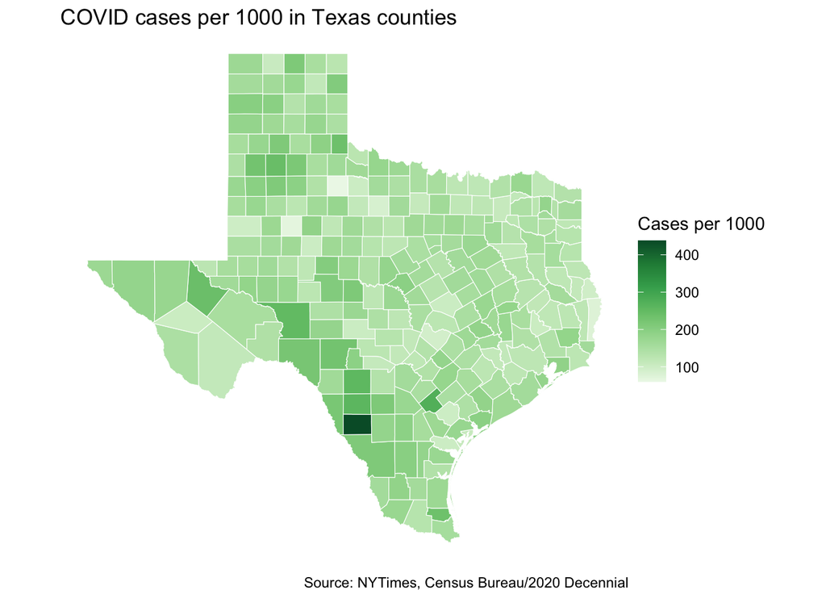

```r
ggplot(tx_rates) +
  geom_sf(aes(fill = cases_per_pop), color = "white", size = .2) +
  theme_void() +
  labs(
    title = "COVID cases per 1000 in Texas counties",
    caption = "Source: NYTimes, Census Bureau/2020 Decennial"
  ) +
  scale_fill_distiller(
    palette = "Greens",
    direction = 1,
    name = "Cases per 1000"
  )
```

### Deaths per 1000

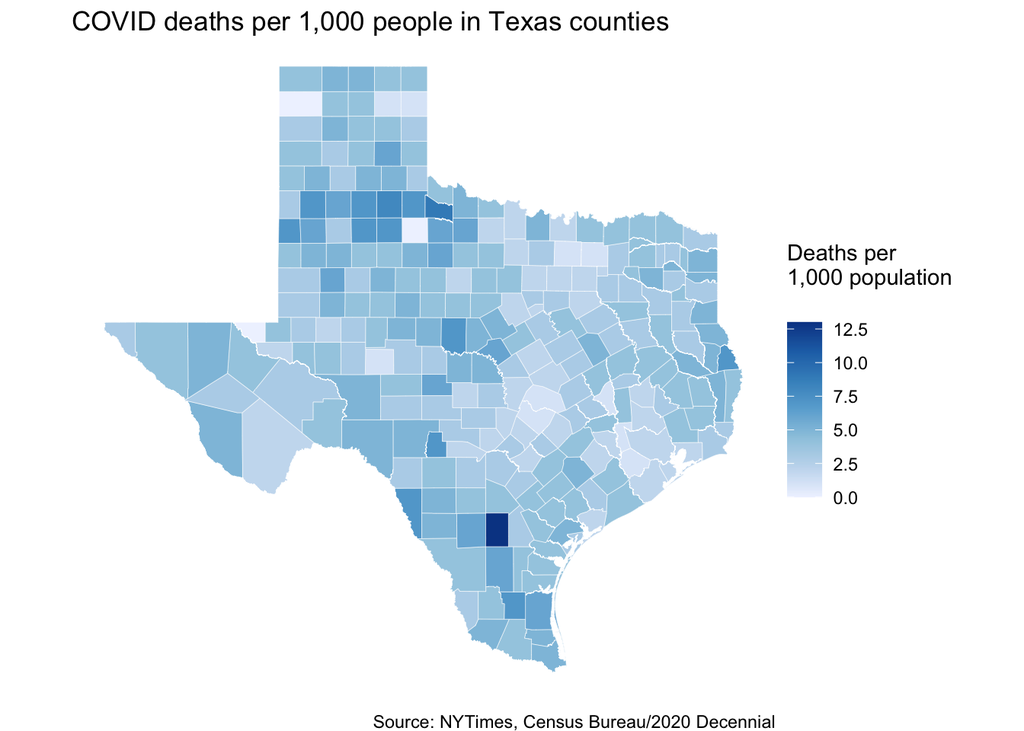

```r
ggplot(tx_rates) +
  geom_sf(aes(fill = deaths_per_pop), color = "white", size = .1) +
  theme_void() +
  labs(
    title = "COVID deaths per 1,000 people in Texas counties",
    caption = "Source: NYTimes, Census Bureau/2020 Decennial"
  ) +
  scale_fill_distiller(
    palette = "Blues",
    direction = 1,
    name = "Deaths per\n1,000 population\n"
  )
```

## Failed join

You have to start with the tibble that has the geometry. This one tries to start with the covid data and the result doesn’t work. The error is:

```r
Error: stat_sf requires the following missing aesthetics: geometry Run `rlang::last_error()` to see where the error occurred.
```

The code is commented since it doesn’t work.

```r
# tx_joined_flop <- tx_covid %>%
#   inner_join(tx_pop, by = c("fips" = "geoid"))
#
# tx_joined_flop %>%
#   ggplot() +
#   geom_sf()
```